# Company Names Record Linkage

## Motivation

In the (re)insurance world, there are two main ‘atoms of risk’ which are insured:

- **People** - you, and I. All of us are insured by some policies, such as, for instance, health cover, auto insurance, etc.
- **Companies**. Wether private or public, companies systematically hold insurance policies, such as, for instance, commercial general liability, worker’s compensation, etc.

In the Casualty field (and to a lesser extent in Property), the largest premium volume by far is generated from the second kind of risk atom – companies. It is therefore crucial to know: 1) what companies we have, 2) where there are in our books, and 3) what are their characteristics.

In practice, **monitoring a P&C portfolio is** therefore to an important extent **synonymous with knowing its company content and the various properties of these companies**.

We will now show and explain using a few examples, that quite a few technical hurdles need to first be overcome in order to achieve this.

## Some Use Cases

### 1. Exclusion list

Consider a portfolio/treaty/book containing policies covering some regions (*X_1 , X_2, …*) and some LoBs (*Y_1, Y_2, …*). The senior management of the insurance company *Muster Man Gmbh*, to which the portfolio belongs, decide to issue new compliance rules for the company. From now on:

1. A list of large C02 producing companies deemed unecological will be excluded from any (re)insurance agreement that will be made in the future.
2. Furthermore, the senior management wants to know whether there currently are companies from said list in the in-force portfolio, and how ‘exposed’ we are.

How should one proceed to make this happen?

## Formal Problem statement

Given the Portfolio *P* and the target exclusion list *L* described above, we want to find which companies *p* in *P* belong to *L*, i.e., which match with some companies *l* listed in *L*. In some sense, what we therefore needs to do is a plain&simple **join** between the two tables:

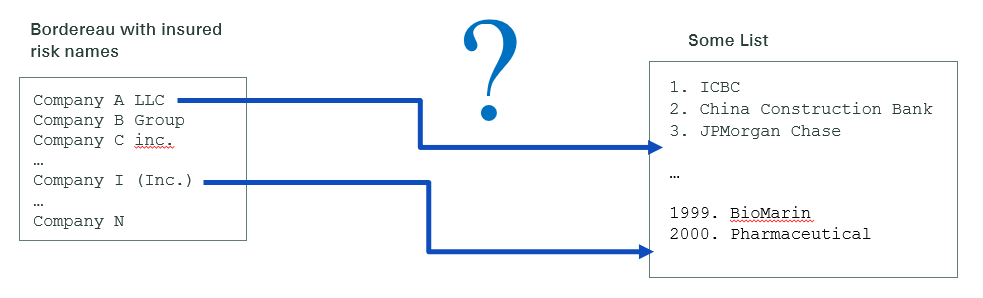

**In practice**, however, this will not work because of the well-known First Law of Data Science:

*“All real-life data is messy”*

To overcome this, we will have to approach this as an **entity linkage problem** - the technical term usually used. Entity linkage can be seen as ‘robust matching’, or matching efficient (to an extent) in the case of noisy data.